# Correlación lineal y Regresión lineal simple

Tanto el valor estandarizado como el *studentized* de los residuos sigue una distribución *t-student*, por lo que es posible obtener el *p-value* asociado. Sí se emplean los *p-values* para extraer conclusiones sobre las observaciones, es importante tener en cuenta que se trata de comparaciones múltiples, por lo que es necesario corregir o controlar la inflación del error de tipo I.

El hecho de que un valor sea atípico o con alto grado de *leverage* no implica que sea influyente en el conjunto del modelo. Sin embargo, si un valor es influyente, suele ser o atípico o de alto *leverage*. Existen diferentes formas de evaluar la influencia de las observaciones:

- La distancia de *Cook* es una medida muy utilizada que combina, en un único valor, la magnitud del residuo y el grado de *leverage*. Valores de *Cook* mayores a 1 suelen considerarse como influyentes.
- Evaluar el cambio en los coeficientes de regresión tras excluir la observación: Se trata de un proceso iterativo en el que cada vez se excluye una observación distinta y se reajusta el modelo. En cada iteración se registra la diferencia en los coeficientes de regresión con y sin la observación, dividida entre el SE del predictor en el modelo sin la observación.
  $$Dfbetas_i = \frac{\hat{\beta} - \hat{\beta_i}}{SE_{\hat{\beta_i}}}$$
  Al tratarse de un valor estandarizado, es sencillo identificar que observaciones influyen más y en que magnitud. En la práctica, se considera una observación influyente cuando $|Dfbetas| > 1$ para un pequeño conjunto de datos y $|Dfbetas| >\sqrt {2/n}$ en general. La función `dfbeta()` realiza esta comparación.

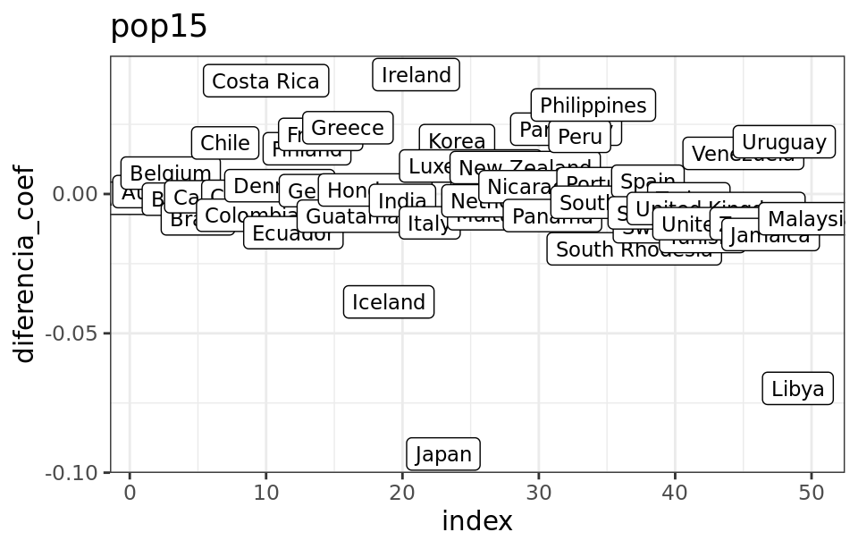

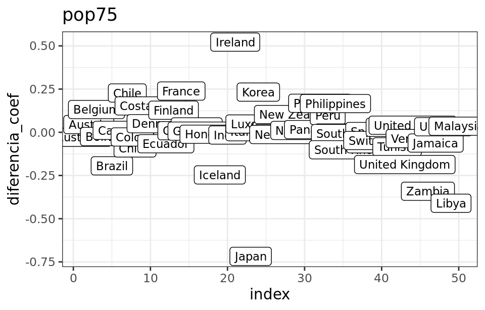

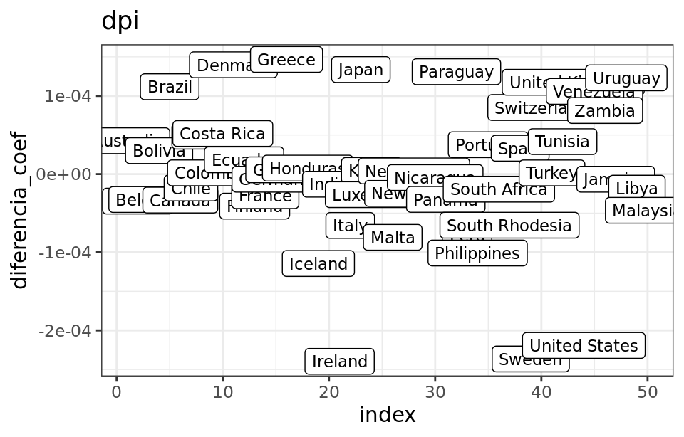

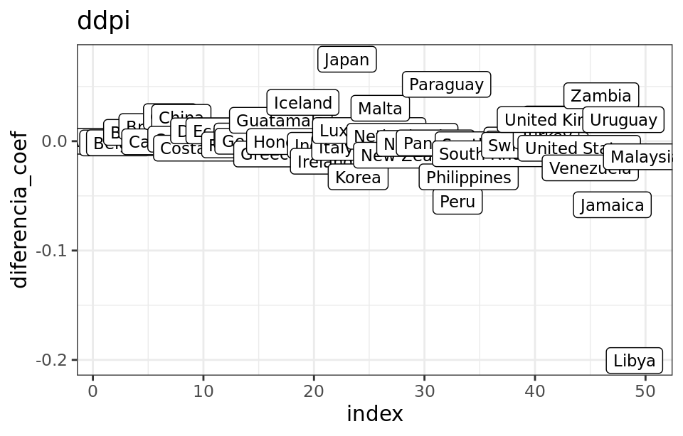

```r
library(faraway)
library(ggplot2)

data("savings")
savings$pais  <- rownames(savings)
modelo_lineal <- lm(sr ~ pop15 + pop75 + dpi + ddpi, savings)

# Se evalúa la influencia de cada observación sobre cada predictor
# El siguiente código es útil tanto para modelos simples como múltiples

predictores <- names(coef(modelo_lineal))[-1]
for (i in seq_along(predictores)) {
diferencia_coef <- dfbeta(modelo_lineal)[, predictores[i]]
diferencia_coef <- data.frame(diferencia_coef = diferencia_coef,
                              pais = names(diferencia_coef),
                              index = 1:length(diferencia_coef))

p <- ggplot(data = diferencia_coef, aes(x = index, y = diferencia_coef)) +
     geom_point() +
     geom_label(aes(label = pais), size = 3) +
     labs(title = predictores[i]) +
     theme_bw()
print(p)
}
```

Para este ejemplo, las observaciones Japan y Libya son las más influyentes sobre el predictor *pop15*. El mismo análisis debería hacerse para cada predictor.

## Regresión lineal con un predictor categórico de dos niveles y su relación con el t-test

*Linear Models with R, by Julian J. Faraway*

El set de datos `sexab` del paquete `faraway` contiene los resultados de un estudio en el que se investigó las secuelas que padecen mujeres adultas debido a abusos sufridos durante la infancia. En una clínica médica se midió el nivel de estrés post-traumático (*ptsd*) y nivel de abuso físico sufrido (*cpa*), ambos en escalas estandarizadas, en 45 mujeres que fueron víctimas en su infancia (*csa*). Las mismas mediciones se registraron para 31 mujeres que no sufrieron ningún tipo de abuso.

```r
library(faraway)
library(ggplot2)

data(sexab)
head(sexab)
```

|  | cpa | ptsd | csa |
| --- | --- | --- | --- |
| 1 | 2.04786 | 9.71365 | Abused |
| 2 | 0.83895 | 6.16933 | Abused |
| 3 | -0.24139 | 15.15926 | Abused |
| 4 | -1.11461 | 11.31277 | Abused |
| 5 | 2.01468 | 9.95384 | Abused |
| 6 | 6.71131 | 9.83884 | Abused |

```r
by(data = sexab, INDICES = sexab$csa, summary)
```

```
## sexab$csa: Abused
##       cpa              ptsd               csa
##  Min.   :-1.115   Min.   : 5.985   Abused   :45
##  1st Qu.: 1.415   1st Qu.: 9.374   NotAbused: 0
##  Median : 2.627   Median :11.313
##  Mean   : 3.075   Mean   :11.941
##  3rd Qu.: 4.317   3rd Qu.:14.901
##  Max.   : 8.647   Max.   :18.993
## ------------------------------------------------------------
## sexab$csa: NotAbused
##       cpa               ptsd               csa
##  Min.   :-3.1204   Min.   :-3.349   Abused   : 0
##  1st Qu.:-0.2299   1st Qu.: 3.544   NotAbused:31
##  Median : 1.3216   Median : 5.794
##  Mean   : 1.3088   Mean   : 4.696
##  3rd Qu.: 2.8309   3rd Qu.: 6.838
##  Max.   : 5.0497   Max.   :10.914
```

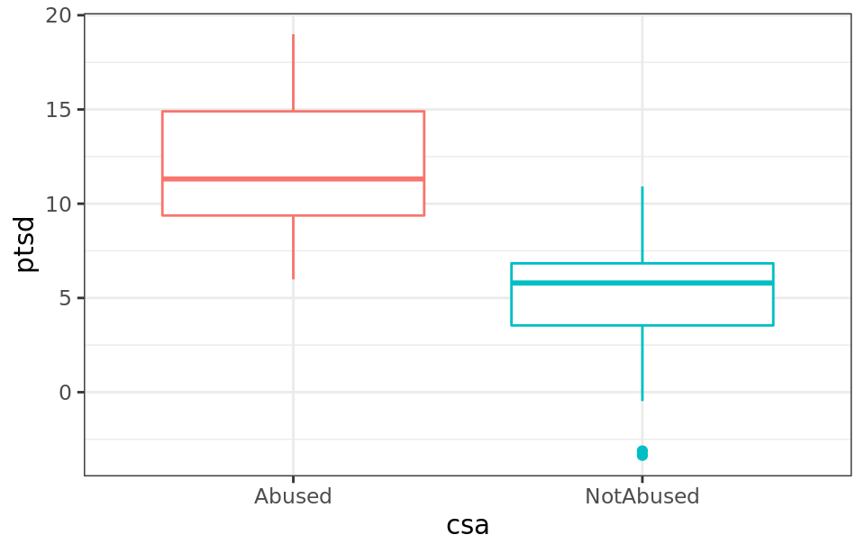

```r
ggplot(data = sexab, aes(x = csa, y = ptsd, colour = csa)) +
  geom_boxplot() +
  theme_bw() +
  theme(legend.position = "none")
```

Se observa que las víctimas de abusos tienen niveles más altos de estrés post-traumático en comparación a las mujeres que no han sufrido abusos.

Una forma de comparar si está diferencia es significativa, es mediante un *t-test*.

```r
# Cálculo de la varianza de cada grupo para determinar si son similares
aggregate(ptsd ~ csa, data = sexab, FUN = var)
```

| csa | ptsd |
| --- | --- |
| Abused | 11.83464 |
| NotAbused | 12.38859 |

```r
t.test(formula = ptsd ~ csa, data = sexab, var.equal = TRUE)
```

```
##
##  Two Sample t-test
##
## data:  ptsd by csa
## t = 8.9387, df = 74, p-value = 2.172e-13
## alternative hypothesis: true difference in means is not equal to 0
## 95 percent confidence interval:
##  5.630165 8.860273
## sample estimates:
##    mean in group Abused mean in group NotAbused
##               11.941093                4.695874
```

El contraste de hipótesis muestra una clara significancia en la diferencia de medias (*p-value = 2.172e-13*).

Este mismo contraste puede realizarse desde la perspectiva de un modelo lineal incluyendo la variable cualitativa como predictor. Para hacerlo, cada uno de los niveles del predictor se tiene que convertir en una variable *dummy* cuyo valor puede ser 0 o 1.

$$ptsd = \beta_0 + \beta_1 dummy_{Abused} + \beta_2 dummy_{NotAbused}$$

$$dummy_i = \left \{ \begin{matrix} 0 & \mbox{la observacion no pertenece al nivel i}
\\ 1 & \mbox{la observacion pertenece al nivel i }\end{matrix}\right.$$

Para cada observación, únicamente una de las variables *dummy* toma el valor 1, por ejemplo, si una mujer sí ha sufrido abusos infantiles, el modelo queda:

$$ptsd = \beta_0 + \beta_1 dummy_{Abused}$$

```r
sexab$abused     <- ifelse(test = sexab$csa == "Abused", yes = 1, no = 0)
sexab$not_abused <- ifelse(test = sexab$csa == "NotAbused", yes = 1, no = 0)
rbind(head(sexab, 3), tail(sexab, 3))
```

|  | cpa | ptsd | csa | abused | not_abused |
| --- | --- | --- | --- | --- | --- |
| 1 | 2.04786 | 9.71365 | Abused | 1 | 0 |
| 2 | 0.83895 | 6.16933 | Abused | 1 | 0 |
| 3 | -0.24139 | 15.15926 | Abused | 1 | 0 |
| 74 | -1.85753 | -0.46996 | NotAbused | 0 | 1 |
| 75 | 2.85253 | 6.84304 | NotAbused | 0 | 1 |
| 76 | 0.81138 | 7.12918 | NotAbused | 0 | 1 |

Se puede observar que la información de las dos variables *dummy* es redundante, al haber solo dos niveles, y dado que solo uno de ellos puede tomar el valor 1, conociendo uno se conoce el otro. Para evitar que aparezca el problema de la singularidad al ajustar el modelo, una de las dos variables se excluye del modelo y se considera como el nivel de referencia.

```r
modelo <- lm(ptsd ~ abused, data = sexab)
summary(modelo)
```

```
##
## Call:
## lm(formula = ptsd ~ abused, data = sexab)
##
## Residuals:
##     Min      1Q  Median      3Q     Max
## -8.0451 -2.3123  0.0951  2.1645  7.0514
##
## Coefficients:
##             Estimate Std. Error t value Pr(>|t|)
## (Intercept)   4.6959     0.6237   7.529 1.00e-10 ***
## abused        7.2452     0.8105   8.939 2.17e-13 ***
## ---
## Signif. codes:  0 '***' 0.001 '**' 0.01 '*' 0.05 '.' 0.1 ' ' 1
##
## Residual standard error: 3.473 on 74 degrees of freedom
## Multiple R-squared:  0.5192, Adjusted R-squared:  0.5127
## F-statistic:  79.9 on 1 and 74 DF,  p-value: 2.172e-13
```

El *p-value* obtenido para el predictor *abused* es el mismo que el obtenido en el *t-test* empleado anteriormente para comparar las medias. El valor estimado de la intersección (4.6959), se corresponde con valor promedio de la variable respuesta en el nivel de referencia. La pendiente estimada (7.2452) se interpreta como el valor promedio de la influencia que tiene el predictor sobre la variable respuesta en comparación al nivel de referencia. En este caso, las mujeres que han sufrido abusos durante su infancia tienen en promedio 7.2452 unidades más de *ptsd* que las que no los han sufrido. Esta cantidad se corresponde con la diferencia de medias de ambos niveles.

```r
# media de ptsd en mujeres víctimas de abusos
mean(sexab[sexab$csa == "Abused", "ptsd"])
```

```
## [1] 11.94109
```

```r
# media de ptsd en mujeres no víctimas de abusos
mean(sexab[sexab$csa == "NotAbused", "ptsd"])
```

```
## [1] 4.695874
```

```r
mean(sexab[sexab$csa == "Abused", "ptsd"]) - mean(sexab[sexab$csa ==
                                                  "NotAbused", "ptsd"])
```

```
## [1] 7.245219
```

Independientemente del nivel que se escoja como referencia, el resultado es el mismo. Lo único que cambia es el valor de la intersección, ya que cambia el nivel de referencia, y el signo de la pendiente.

```r
modelo <- lm(ptsd ~ not_abused, data = sexab)
summary(modelo)
```

```
##
## Call:
## lm(formula = ptsd ~ not_abused, data = sexab)
##
## Residuals:
##     Min      1Q  Median      3Q     Max
## -8.0451 -2.3123  0.0951  2.1645  7.0514
##
## Coefficients:
##             Estimate Std. Error t value Pr(>|t|)
## (Intercept)  11.9411     0.5177  23.067  < 2e-16 ***
## not_abused   -7.2452     0.8105  -8.939 2.17e-13 ***
## ---
## Signif. codes:  0 '***' 0.001 '**' 0.01 '*' 0.05 '.' 0.1 ' ' 1
##
## Residual standard error: 3.473 on 74 degrees of freedom
## Multiple R-squared:  0.5192, Adjusted R-squared:  0.5127
## F-statistic:  79.9 on 1 and 74 DF,  p-value: 2.172e-13
```

En `R` la función `lm()` identifica automáticamente si un predictor es de tipo cualitativo y escoge como nivel de referencia el primero en base al orden alfabético.

```r
modelo <- lm(ptsd ~ csa, data = sexab)
summary(modelo)
```

```
##
## Call:
## lm(formula = ptsd ~ csa, data = sexab)
##
## Residuals:
##     Min      1Q  Median      3Q     Max
## -8.0451 -2.3123  0.0951  2.1645  7.0514
##
## Coefficients:
##              Estimate Std. Error t value Pr(>|t|)
## (Intercept)   11.9411     0.5177  23.067  < 2e-16 ***
## csaNotAbused  -7.2452     0.8105  -8.939 2.17e-13 ***
## ---
## Signif. codes:  0 '***' 0.001 '**' 0.01 '*' 0.05 '.' 0.1 ' ' 1
##
## Residual standard error: 3.473 on 74 degrees of freedom
## Multiple R-squared:  0.5192, Adjusted R-squared:  0.5127
## F-statistic:  79.9 on 1 and 74 DF,  p-value: 2.172e-13
```

Si se desea especificar cual debe ser el nivel de referencia empleado por `lm()`, se puede recurrir a la función `relevel()`

```r
sexab$csa <- relevel(sexab$csa, ref = "NotAbused")
summary(lm(ptsd ~ csa, data = sexab))
```

```
##
## Call:
## lm(formula = ptsd ~ csa, data = sexab)
##
## Residuals:
##     Min      1Q  Median      3Q     Max
## -8.0451 -2.3123  0.0951  2.1645  7.0514
##
## Coefficients:
##             Estimate Std. Error t value Pr(>|t|)
## (Intercept)   4.6959     0.6237   7.529 1.00e-10 ***
## csaAbused     7.2452     0.8105   8.939 2.17e-13 ***
## ---
## Signif. codes:  0 '***' 0.001 '**' 0.01 '*' 0.05 '.' 0.1 ' ' 1
##
## Residual standard error: 3.473 on 74 degrees of freedom
## Multiple R-squared:  0.5192, Adjusted R-squared:  0.5127
## F-statistic:  79.9 on 1 and 74 DF,  p-value: 2.172e-13
```

Es importante tener en cuenta que los *p-values* obtenidos por un *t-test* y por un modelo lineal que contenga un predictor cualitativo con dos niveles serán los mismos siempre y cuando el *t-test* no incluya una corrección de varianzas desiguales.

## Estimación de los parámetros de un modelo de regresión lineal mediante descenso de gradiente

[Machine Learning by Andrew Ng, Stanford University](https://es.coursera.org/learn/machine-learning/lecture/kCvQc/gradient-descent-for-linear-regression)

Considérese el modelo de regresión lineal simple:

$$Y = \beta_0 + \beta_1X_1 + \epsilon$$

Dada una muestra de entrenamiento, el ajuste de un modelo lineal consiste en encontrar los parámetros estimados ($\hat{\beta}_0, \hat{\beta}_1$) que definen la recta que pasa más cerca de todos los puntos. Para ello se tiene que minimizar la suma de cuadrados residuales:

$$RSS(\beta_0, \beta_1) = \sum^n_{i = 1}(y_i - (\beta_0 + \beta_1x_{i}))^2$$
Si bien, para este problema en cuestión, existe una solución explicita con la que obtener el mínimo:

$$\hat{\beta}_1 = \frac{\sum^n_{i=1}(x_i - \overline{x})(y_i - \overline{y})}{\sum^n_{i=1}(x_i - \overline{x})^2}$$
$$\hat{\beta}_0 = \overline{y} - \hat{\beta}_1\overline{x}$$
en muchos otros casos no existe tal posibilidad, haciendo necesaria la utilización de algoritmos de optimización. La sencillez del problema de regresión lineal simple hace que sea un buen ejemplo para ilustrar cómo se solucionan problemas de optimización. Además, esta función tiene una propiedad muy interesante que facilita mucho su optimización, se trata de una función convexa, por lo que tiene un único mínimo que coincide con el mínimo global.

Los algoritmos de optimización siguen un proceso iterativo en el que, partiendo de una posición inicial dentro del dominio de la función, realizan desplazamientos en la dirección correcta hasta alcanzar el mínimo. Para poder llevar a cabo el proceso se necesita:

- La función objetivo a minimizar.
- La posición desde la que iniciar la búsqueda.
- La distancia (*step*) que se va a desplazar el algoritmo en cada iteración de búsqueda. Es importante escoger un *step* adecuado en cada escenario. Si es muy pequeño, se tardará demasiado en llegar al mínimo y, si es demasiado grande, el algoritmo saltará de una región a otra pasando por encima del mínimo sin alcanzarlo.
- La dirección de búsqueda en la que se produce el desplazamiento.
- La tolerancia: Al tratarse de un algoritmo iterativo, hay que indicar una regla de parada. Lo idóneo es que el algoritmo se detenga al encontrar el mínimo, pero como normalmente se desconoce cuál es, hay que conseguir que se pare lo más cerca posible. Una forma de cuantificar la proximidad al mínimo es controlar cuanto desciende el valor de la función entre iteraciones consecutivas. Si el descenso es muy pequeño, significa que se encuentra muy cerca del valor. La tolerancia se define como un valor tal que, si la diferencia en el descenso es menor o igual, se considera que se ha alcanzado el mínimo (el algoritmo converge). Una alternativa a calcular la distancia entre las dos iteraciones es medir la longitud del vector gradiente en cada iteración. Si su longitud es muy pequeña, también lo es la distancia al mínimo.
- Iteraciones máximas: Si la posición de inicio en la búsqueda está muy alejada del mínimo de la función y el *step* es muy pequeño, se pueden necesitar muchas iteraciones para alcanzarlo. Para evitar un proceso iterativo excesivamente largo, se suele establecer un número máximo de iteraciones permitidas.

**Optimización por el método de descenso de gradiente**

El algoritmo de descenso de gradiente se caracteriza porque emplea como dirección de búsqueda aquella en la que la función desciende en mayor medida. Esta dirección se corresponde con el valor negativo del gradiente de la función. El gradiente de la función es el vector formado por las derivadas parciales de la función respecto a cada variable.

La función objetivo a optimizar en regresión lineal es la suma de los residuos cuadrados:

$$J(\beta_0 , \beta_1) = \sum^n_{i = 1}(y_i - (\beta_0 + \beta_1x_{i} ))^2 = \sum^n_{i = 1}(y_i - \beta_0 - \beta_1x_{i})^2$$

Para facilitar posteriores simplificaciones, se multiplica la función por el factor $\frac{1}{2}$.

$$J(\beta_0 , \beta_1) = \frac{1}{2} \sum^n_{i = 1}(y_i - \beta_0 - \beta_1x_{i})^2$$

Las derivadas parciales de la función respecto a cada una de las variables, en este caso, son:

$$\frac{dJ}{d(\beta_0)} = 2 * \frac{1}{2}\sum^n_{i = 1}(y_i - \beta_0 - \beta_1x_{i}) * -1 = -\sum^n_{i = 1}(y_i - \beta_0 - \beta_1x_{i})$$

$$\frac{dJ}{d(\beta_1)} = 2 * \frac{1}{2}\sum^n_{i = 1}(y_i - \beta_0 - \beta_1x_{i}) * -x_i = -\sum^n_{i = 1}(y_i - \beta_0 - \beta_1x_{i}) x_i$$

El vector gradiente para un modelo lineal simple es por lo tanto:

$$\begin{bmatrix}{-\sum^n_{i = 1}(y_i - \beta_0 - \beta_1x_{i})}\\{-\sum^n_{i = 1}(y_i - \beta_0 - \beta_1x_{i})x_i}\end{bmatrix}$$

**Algoritmo: Método de descenso de gradiente para $J(\beta_0 , \beta_1)$**

1. Seleccionar valores iniciales $\hat{\beta}_0, \hat{\beta}_1, t>0$
2. Iniciar un proceso iterativo en el que:
   - $\hat{\beta}_0 = \hat{\beta}_0 - t * -\sum^n_{i = 1}(y_i - \beta_0 - \beta_1x_{i})$
   - $\hat{\beta}_1 = \hat{\beta}_1 - t * -\sum^n_{i = 1}(y_i - \beta_0 - \beta_1x_{i})x_i$

hasta alcanzar una condición de parada.

Véase ahora un ejemplo práctico. En primer lugar, se simula una muestra a partir de una función conocida en la que el usuario determina los parámetros poblacionales. Conocer los parámetros poblacionales permitirá evaluar cómo de buenas son las estimaciones obtenidas.

```r
n <- 100      # Tamaño de la muestra
set.seed(123) # Para permitir reproducibilidad
x <- runif(n, min = 0, max = 5) # n puntos aleatorios en el intervalo [min,max]
beta0 <- 2    # Parámetro beta0 del modelo
beta1 <- 5    # Parámetro beta1 del modelo
set.seed(123) # Para permitir reproducibilidad
epsilon <- rnorm(n, sd = 1) # error (con desviación típica sd=1)
y <- beta0 + beta1 * x + epsilon # cálculo de cada y_i
datos <- data.frame(x, y)
head(datos)
```

|  | x | y |
| --- | --- | --- |
| 1 | 1.4378876 | 8.628962 |
| 2 | 3.9415257 | 21.477451 |
| 3 | 2.0448846 | 13.783131 |
| 4 | 4.4150870 | 24.145943 |
| 5 | 4.7023364 | 25.640970 |
| 6 | 0.2277825 | 4.853977 |

Véase los valores estimados por la función `lm()` que aplica la solución explicita.

```r
modelo_lm <- lm(y ~ x , data = datos)
coefficients(modelo_lm)
```

```
## (Intercept)           x
##    2.117657    4.989068
```

Como era de esperar, las estimaciones de los coeficientes de regresión obtenidos mediante `lm()` se aproximan mucho a los parámetros poblacionales.

**Ajuste del modelo por optimización de la suma de residuos cuadrados**

```r
# FUNCIÓN OBJETIVO A MINIMIZAR
# =============================================================================

sum_residuos <- function(x, y, beta_0, beta_1){
  return(sum((y - (beta_0 + beta_1 * x))^2))
}

# CÁLCULO DE GRADIENTE PARA MODELO LINEAL SIMPLE
# =============================================================================
calc_gradiente <- function(beta_0, beta_1, x, y){
  # beta_0: valor de intersección
  # beta_1: coeficiente de regresión del predictor
  # x: valores del predictor observados en la muestra
  # y: valores de la variable respuesta observados en la muestra
  grad_1 <- sum(y - beta_0 - beta_1 * x)
  grad_2 <- sum((y - beta_0 - beta_1 * x) * x)
  return(c(grad_1, grad_2))
}

# OPTIMIZACIÓN
# =============================================================================
optimizacion_grad <- function(beta_0 = 0, beta_1 = 0, x, y, t = 0.001,
                              max_iter = 10000, tolerancia = 1e-10){

  # Matriz para almacenar el valor de las estimaciones en cada iteración
  estimaciones <- matrix(NA, nrow = max_iter, ncol = 4)
  colnames(estimaciones) <- c("iteracion", "beta0", "beta1", "residuos")

  for(i in 1:max_iter){

    gradiente <- calc_gradiente(beta_0 = beta_0, beta_1 = beta_1, x = x, y = y)

    if(sqrt(sum(gradiente^2)) < tolerancia){
      # Si el tamaño del vector es menor que la tolerancia,
      # se considera que el proceso a llegado a convergencia.
      message("El algoritmo ha alcanzado convergencia")
      break
    }else{
    estimaciones[i, 1] <- i
    estimaciones[i, 2] <- beta_0
    estimaciones[i, 3] <- beta_1
    estimaciones[i, 4] <- sum_residuos(x, y, beta_0, beta_1)
    beta_0 <- beta_0 + t * gradiente[1]
    beta_1 <- beta_1 + t * gradiente[2]
    }
  }
  print(paste("Estimación de beta_0:", beta_0))
  print(paste("Estimación de beta_1;", beta_1))
  print(paste("Número de iteraciones:", i))
  print(paste("Suma de residuos cuadrados:", estimaciones[i-1, 4]))

  return(list(beta_0 = beta_0,
              beta_1 = beta_1,
              iteraciones = i,
              estimaciones = as.data.frame(na.omit(estimaciones))
              )
  )
}

resultados <- optimizacion_grad(beta_0 = 10, beta_1 = 10, x = datos$x,
                                y = datos$y, t = 0.001, max_iter = 10000,
                                tolerancia = 1e-6)
```

```
## [1] "Estimación de beta_0: 2.11765688165228"
## [1] "Estimación de beta_1; 4.98906810875534"
## [1] "Número de iteraciones: 830"
## [1] "Suma de residuos cuadrados: 82.4660264805963"
```

Empleando un valor *t = 0.001*, los valores estimados mediante optimización por descenso de gradiente son casi idénticos a los obtenidos mediante la función `lm()`.

Los siguientes gráficos muestran la evolución de los parámetros estimados y el error tras cada iteración.

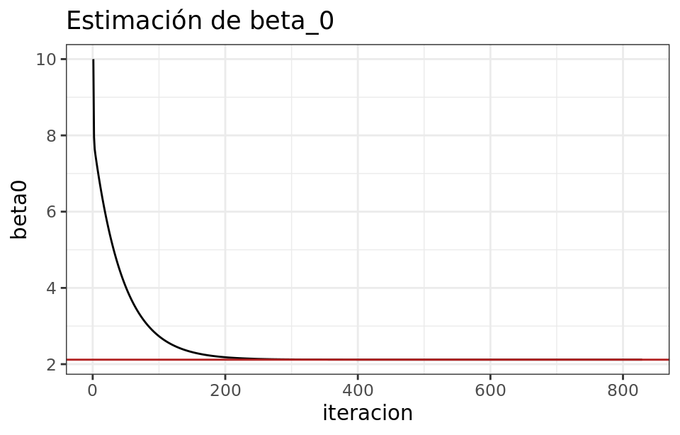

```r
library(ggplot2)

ggplot(data = resultados$estimaciones,
      aes(x = iteracion, y = beta0)) +
geom_path() +
geom_hline(yintercept = modelo_lm$coefficients[1], color = "firebrick") +
theme_bw() +
ggtitle("Estimación de beta_0")
```

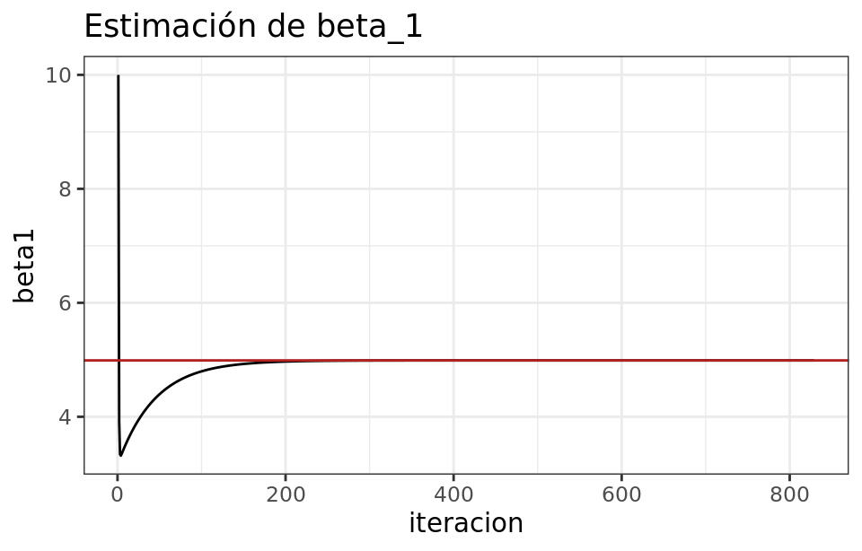

```r
ggplot(data = resultados$estimaciones,
       aes(x = iteracion, y = beta1)) +
geom_path() +
geom_hline(yintercept = modelo_lm$coefficients[2], color = "firebrick") +
theme_bw() +
ggtitle("Estimación de beta_1")
```

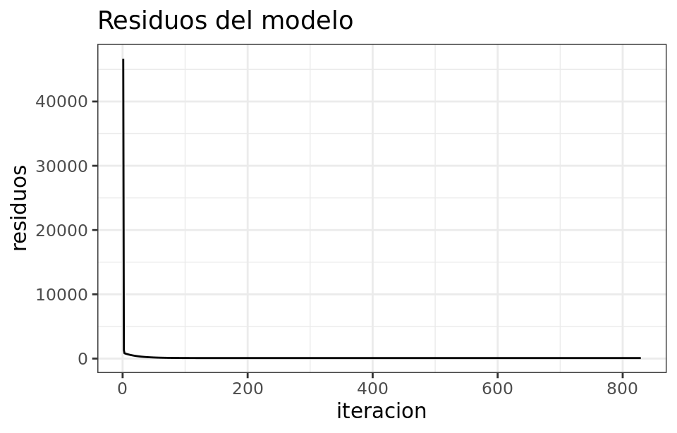

```r
ggplot(data = resultados$estimaciones,
       aes(x = iteracion, y = residuos)) +
geom_path() +
theme_bw() +
ggtitle("Residuos del modelo")
```

Es importante evaluar gráficamente la evolución de los parámetros estimados y de la función objetivo, sobre todo esta última, ya que aporta mucha información sobre si el algoritmo está aproximándose al mínimo (descenso en la curva) y si está llegando a convergencia (estabilización de la curva).

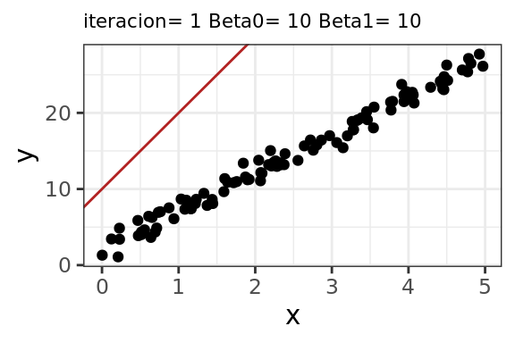

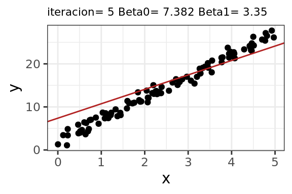

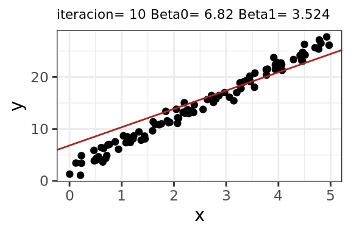

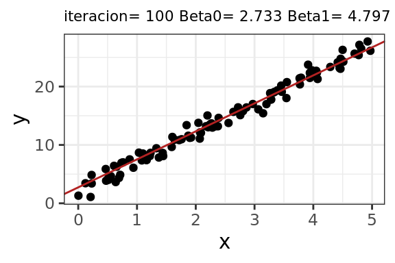

```r
for(i in c(1,5,10,100)) {
  beta_0 <- round(resultados$estimaciones$beta0[i],3)
    beta_1 <- round(resultados$estimaciones$beta1[i],3)
   p  <- ggplot(data = datos, aes(x = x, y = y)) +
         geom_point() +
         geom_abline(intercept = beta_0, slope = beta_1, color = "firebrick") +
         ggtitle(paste("iteracion=", i, "Beta0=", beta_0, "Beta1=",beta_1)) +
         theme_bw() +
         theme(plot.title = element_text(size = 8))
   print(p)
}
```

Este método está muy influenciado por el tamaño de *t*. Para valores altos, la suma de cuadrados residuales puede ser un valor demasiado grande para que el software empleado lo almacene. Por ejemplo, este mismo código ejecutado para una muestra de tamaño *n=1000* devuelve error. Las simulaciones que he realizado parecen indicar que empleando un valor de *t* aproximadamente de *1/(10n)* se adapta bastante bien.

```r
n <- 10000
set.seed(123)
x <- runif(n, min = 0, max = 5)
beta0 <- 2
beta1 <- 5
set.seed(123)
epsilon <- rnorm(n, sd = 1)
y <- beta0 + beta1 * x + epsilon
datos2 <- data.frame(x, y)

resultados <- optimizacion_grad(beta_0 = 10, beta_1 = 10, x = datos2$x,
                                y = datos2$y, t = 1/(10*length(x)),
                                max_iter = 10000, tolerancia = 1e-6)
```

```
## [1] "Estimación de beta_0: 1.99327105964167"
## [1] "Estimación de beta_1; 5.0017514798928"
## [1] "Número de iteraciones: 1015"
## [1] "Suma de residuos cuadrados: 9971.6909756411"
```

**Ajuste del modelo por optimización de la media de residuos cuadrados**

En lugar de minimizar la suma de cuadrados residuales, también se puede minimizar la media de los residuos cuadrados.

```r
# FUNCIÓN OBJETIVO A MINIMIZAR
# =============================================================================

mean_residuos <- function(x, y, beta_0, beta_1){
  return((1/length(x)) * sum((y - (beta_0 + beta_1 * x))^2))
}

# CÁLCULO DE GRADIENTE PARA MODELO LINEAL SIMPLE
# =============================================================================
calc_gradiente <- function(beta_0, beta_1, x, y){
  # beta_0: valor de intersección
  # beta_1: coeficiente de regresión del predictor
  # x: valores del predictor observados en la muestra
  # y: valores de la variable respuesta observados en la muestra
  grad_1 <- (1/length(x)) * sum(y - beta_0 - beta_1 * x)
  grad_2 <- (1/length(x)) * sum((y - beta_0 - beta_1 * x) * x)
  return(c(grad_1, grad_2))
}

# OPTIMIZACIÓN
# =============================================================================
optimizacion_grad <- function(beta_0 = 0, beta_1 = 0, x, y, t = 0.001,
                              max_iter = 10000, tolerancia = 1e-10){

  # Matriz para almacenar el valor de las estimaciones en cada iteración
  estimaciones <- matrix(NA, nrow = max_iter, ncol = 4)
  colnames(estimaciones) <- c("iteracion", "beta0", "beta1", "residuos")

  for(i in 1:max_iter){

    gradiente <- calc_gradiente(beta_0 = beta_0, beta_1 = beta_1, x = x, y = y)

    if(sqrt(sum(gradiente^2)) < tolerancia){
      # Si el tamaño del vector es menor que la tolerancia,
      # se considera que el proceso a llegado a convergencia.
      message("El algoritmo ha alcanzado convergencia")
      break
    }else{
    estimaciones[i, 1] <- i
    estimaciones[i, 2] <- beta_0
    estimaciones[i, 3] <- beta_1
    estimaciones[i, 4] <- mean_residuos(x, y, beta_0, beta_1)
    beta_0 <- beta_0 + t * gradiente[1]
    beta_1 <- beta_1 + t * gradiente[2]
    }
  }
  print(paste("Estimación de beta_0:", beta_0))
  print(paste("Estimación de beta_1;", beta_1))
  print(paste("Número de iteraciones:", i))
  print(paste("Media residuos cuadrados:", estimaciones[i-1, 4]))

  return(list(beta_0 = beta_0,
              beta_1 = beta_1,
              iteraciones = i,
              estimaciones = as.data.frame(na.omit(estimaciones))
              )
  )
}

resultados <- optimizacion_grad(beta_0 = 10, beta_1 = 10, x = datos$x,
                                y = datos$y, t = 0.1, max_iter = 10000,
                                tolerancia = 1e-6)
```

```
## [1] "Estimación de beta_0: 2.11766110184018"
## [1] "Estimación de beta_1; 4.98906679390207"
## [1] "Número de iteraciones: 626"
## [1] "Media residuos cuadrados: 0.824660264810621"
```

Empleando como función objetivo la media de los residuos cuadrados, el valor de *t* puede ser mayor que cuando se utiliza la suma de los residuos cuadrados (partiendo del mismo punto inicial).

## Método de descenso de gradiente estocástico (Stochastic Gradient Descent)

[Machine Learning by Andrew Ng, Stanford University](https://es.coursera.org/learn/machine-learning/lecture/DoRHJ/stochastic-gradient-descent)

En el método de descenso de gradiente visto en el apartado anterior, se utiliza la muestra de entrenamiento al completo para cada actualización del valor de los parámetros (cada iteración). Esto supone un alto coste computacional cuando la muestra contiene muchas observaciones ya que, con frecuencia, se necesitan cientos o miles de actualizaciones hasta llegar a una estimación aceptable. Existe una alternativa al método de descenso de gradiente llamada gradiente estocástico que proporciona buenos resultados. La idea es que, en lugar de esperar a evaluar todas las observaciones para actualizar los parámetros, se puedan ir actualizando con cada observación por separado. El algoritmo para el caso particular del modelo de regresión lineal simple es el siguiente:

**Algoritmo: Método de descenso de gradiente estocástico para $J(\beta_0 , \beta_1)$**

1. Ordenación aleatoria de las observaciones
2. Seleccionar valores iniciales $\hat{\beta}_0, \hat{\beta}_1, t>0$
3. Repetir:
- Iniciar un proceso iterativo en el que para $i = 1,..., n$
  - $\hat{\beta}_0 = \hat{\beta}_0 - t * -(y_i - \beta_0 - \beta_1x_{i})$
  - $\hat{\beta}_1 = \hat{\beta}_1 - t * -x_i(y_i - \beta_0 - \beta_1x_{i})$

hasta alcanzar una condición de parada.

Con este método se actualiza el valor de los parámetros con cada observación de la muestra de entrenamiento, evitando utilizar todos los datos en cada iteración. Puede observarse que el algoritmo tiene un bucle externo que engloba a un bucle interno de actualización de parámetros. Este blucle externo determina el número de veces que se recorre el set de datos completo en la optimización. En el ámbito de *machine learning* se le conoce como *epochs*. Su valor óptimo depende del tamaño del set de datos de entrenamiento, valores entre 1 y 10 suelen generar buenos resultados.

```r
opt_grad_estoc <- function(beta_0 = 10, beta_1 = 10, x, y, t = 0.01,
                           epochs = 10){

  # Matriz para almacenar el valor de las estimaciones en cada epoch
  estimaciones <- matrix(NA, nrow = epochs, ncol = 3)
  colnames(estimaciones) <- c("epoch", "beta0", "beta1")

  for(j in 1:epochs){

    estimaciones[j, 1] <- j
    estimaciones[j, 2] <- beta_0
    estimaciones[j, 3] <- beta_1

    for(i in 1:length(x)){

      beta_0 <- beta_0 + t * (y[i] - beta_0 - beta_1 * x[i])
      beta_1 <- beta_1 + t *  x[i] * (y[i] - beta_0 - beta_1 * x[i])

     }
  }

  print(paste("Estimación de beta_0:", beta_0))
  print(paste("Estimación de beta_1;", beta_1))
  print(paste("Número de epochs:", j))

  return(list(beta_0 = beta_0,
              beta_1 = beta_1,
              epochs = j,
              estimaciones = estimaciones))
}

resultados <- opt_grad_estoc(beta_0 = 10, beta_1 = 10, x = datos2$x,
                             y = datos2$y, t = 0.01, epochs = 10)
```

```
## [1] "Estimación de beta_0: 1.8814987610849"
## [1] "Estimación de beta_1; 4.99802652516896"
## [1] "Número de epochs: 10"
```

# Información sesión

```r
sesion_info <- devtools::session_info()
dplyr::select(
  tibble::as_tibble(sesion_info$packages),
  c(package, loadedversion, source)
)
```

# Bibliografía

Linear Models with R by Julian J.Faraway

An Introduction to Statistical Learning: with Applications in R (Springer Texts in Statistics)

OpenIntro Statistics: Fourth Edition by David Diez, Mine Çetinkaya-Rundel, Christopher Barr

Extending the Linear Model with R: Generalized Linear, Mixed Effects and Nonparametric Regression Models by Julian J.Faraway

Introduction to Machine Learning with Python: A Guide for Data Scientists

Points of Significance: Association, correlation and causation. Naomi Altman & Martin Krzywinski Nature Methods

Points of Significance: Simple linear regression Naomi Altman & Martin Krzywinski. Nature Methods

Resampling Data: Using a Statistical Jackknife S. Sawyer | Washington University | March 11, 2005

https://en.wikipedia.org/wiki/Resampling_(statistics)#Jackknife

The Trusty Jackknife Method identifies outliers and bias in statistical estimates by I. Elaine Allen and Christopher A. Seaman

**¿Cómo citar este documento?**

Correlación lineal y Regresión lineal simple por Joaquín Amat Rodrigo, disponible con licencia CC BY-NC-SA 4.0 en https://www.cienciadedatos.net/documentos/24_correlacion_y_regresion_lineal

**¿Te ha gustado el artículo? Tu ayuda es importante**

Mantener un sitio web tiene unos costes elevados, tu contribución me ayudará a seguir generando contenido divulgativo gratuito. ¡Muchísimas gracias! 😊

Este material, creado por Joaquín Amat Rodrigo, tiene licencia [Attribution-NonCommercial-ShareAlike 4.0 International](https://creativecommons.org/licenses/by-nc-sa/4.0/).

Se permite:

- Compartir: copiar y redistribuir el material en cualquier medio o formato.
- Adaptar: remezclar, transformar y crear a partir del material.

Bajo los siguientes términos:

- Atribución: Debes otorgar [el crédito adecuado](https://creativecommons.org/licenses/by-nc-sa/4.0/deed.es#ref-appropriate-credit), proporcionar un enlace a la licencia e [indicar si se realizaron cambios](https://creativecommons.org/licenses/by-nc-sa/4.0/deed.es#ref-indicate-changes). Puedes hacerlo de cualquier manera razonable, pero no de una forma que sugiera que el licenciante te respalda o respalda tu uso.
- NoComercial: No puedes utilizar el material para [fines comerciales](https://creativecommons.org/licenses/by-nc-sa/4.0/deed.es#ref-commercial-purposes).
- CompartirIgual: Si remezclas, transformas o creas a partir del material, debes distribuir tus contribuciones bajo la [misma licencia](https://creativecommons.org/licenses/by-nc-sa/4.0/deed.es#ref-same-license) que el original.